# Estimation du nombres d’espèces de Lombrics tropicaux

# Données

```r
data <- read.csv2("data/Tropical.csv")
data <- data[data$S > 0, ]
```

Les données sont :

- Le nombre d’unités de temps passé depuis le début de la période d’étude $Y_i=i$,

```r
Y <- data$Y
```

- Le nombre d’espèces découvertes $S_i$ à chaque unité de temps,

```r
S <- data$S
```

- Le nombre cumulé d’espèces découvertes, qui augmente à chaque unité de temps,

```r
# Valeur initiale
S_0 <- 0
```

- Le nombre de taxonomistes actifs $T_i$ à chaque unité de temps,

```r
T <- data$T
```

# Inférence

La variable expliquée est $S$. Le nombre d’espèces décrites au début de la période d’étude est $S_0$.

La variable explicative est $T$ : le nombre de taxonomistes actifs chaque année.

Les paramètres sont $\theta = (\beta_1, \beta_2, S_T, \sigma)$.

## Vraisemblance

La vraisemblance des données `S` sachant les paramètres est calculée :

```r
# Arguments: S : nombre d'espèces découvertes au temps i T : nombre de
# taxonomistes Y : année (temps) S_0 : nombres d'espèces connues au début theta
# : paramètres
ll_S_theta <- function(S, T, Y, S_0, theta) {
    nTemps <- length(Y)
    # Stockage des prédictions du modèle et de leur cumul
    prediction <- numeric(nTemps)
    sum_S <- numeric(nTemps + 1)
    # Valeur initiale
    sum_S[1] <- S_0
    # Valeurs prédites par le modèle
    for (i in 1:nTemps) {
        prediction[i] <- (theta[3] * theta[1] * T[i] + theta[2] * theta[3] * T[i] *
            Y[i] + theta[1] * T[i] * sum_S[i] + theta[2] * T[i] * Y[i] * sum_S[i])
        sum_S[i + 1] <- sum_S[i] + prediction[i]
    }
    # Log-vraisemblance de chaque valeur de y
    likelihoods <- suppressWarnings(dnorm(log(S), mean = log(prediction), sd = theta[4],
        log = TRUE))
    # Possibilité de NaN
    ll <- sum(likelihoods)
    # Vraisemblance nulle dans ce cas
    if (is.na(ll))
        ll <- -Inf
    return(ll)
}
```

La vraisemblance des paramètres est:

```r
ll_prior <- function(theta, S_0) {
    # Log-vraisemblance de chaque paramètre dans sa loi a priori
    prior1 <- dunif(theta[1], min = 0, max = 1, log = TRUE)  # beta_1
    prior2 <- dunif(theta[2], min = 0, max = 1, log = TRUE)  # beta_2
    prior3 <- dunif(theta[3], min = S_0, max = 1e+05, log = TRUE)  # S_T
    prior4 <- dunif(theta[4], min = 0, max = 1000, log = TRUE)  # sigma
    return(prior1 + prior2 + prior3 + prior4)
}
```

## Parcours de l’espace des paramètres

Fonction de proposition :

```r
proposal <- function(theta, sigma_prop) {
    return(rnorm(length(theta), mean = theta, sd = sigma_prop))
}
```

Chaîne de Markov :

```r
MetropolisMCMC <- function(S, T, Y, S_0, sigma_prop, theta_0, iterations) {
    # Stockage. Chaque ligne du tableau contient une itération ; les colonnes
    # contiennent theta
    chain <- matrix(nrow = iterations + 1, ncol = length(theta_0))
    # Noms des paramètres
    colnames(chain) <- names(theta_0)
    # Stockage des vraisemblances (1: ll_S_theta, 2: ll_prior)
    ll_data <- matrix(nrow = iterations + 1, ncol = 2)
    colnames(ll_data) <- c("data", "prior")
    # Valeurs initiales
    chain[1, ] <- theta_0
    ll_data[1, 1] <- ll_S_theta(S, T, Y, S_0, theta_0)
    ll_data[1, 2] <- ll_prior(theta_0, S_0)
    # Initialisation d'une barre de progression
    pgb <- txtProgressBar(min = 0, max = iterations)
    # Chaîne de Markov
    for (i in 1:iterations) {
        # Proposition d'une valeur de theta
        theta_proposal <- proposal(chain[i, ], sigma_prop)
        # Vraisemblances
        ll_data[i + 1, 1] <- ll_S_theta(S, T, Y, S_0, theta_proposal)
        ll_data[i + 1, 2] <- ll_prior(theta_proposal, S_0)
        # Acceptation
        if (sum(ll_data[i, ]) == -Inf) {
            # Acceptation systématique si la vraisemblance précédente était
            # nulle
            l_ratio <- Inf
        } else {
            # Rapport de vraisemblance entre la proposition et la valeur
            # précédente de theta
            l_ratio <- exp(sum(ll_data[i + 1, ]) - sum(ll_data[i, ]))
        }
        # Acceptation ou non
        if (runif(1) < l_ratio) {
            chain[i + 1, ] <- theta_proposal
        } else {
            chain[i + 1, ] <- chain[i, ]
            # Conserver les valeurs de vraisemblance
            ll_data[i + 1, ] <- ll_data[i, ]
        }
        setTxtProgressBar(pgb, i)
    }
    # Retour d'un tableau complet: theta et vraisemblance
    return(cbind(chain, LogVraisemblance = ll_data))
}
```

## Exécution

```r
# Nombre de pas de la chaîne
iterations <- 1e+7
# Ecart-type de la marche aléatoire (pour chaque paramètre)
sigma_prop <- c(1E-3, 1E-5, 1E4, 1)/10
# Valeur initiale des paramètres
theta_0 <- c(
  1E-2,  # beta_1
  1E-6,  # beta_2
  1E4,   # S_T
  1     # sigma
  )
names(theta_0) <- c("beta_1", "beta_2", "S_T", "EcartType")
# Lancement de la chaîne de Markov
chain <- MetropolisMCMC(S, T, Y, S_0, sigma_prop, theta_0, iterations)
```

## Résultats

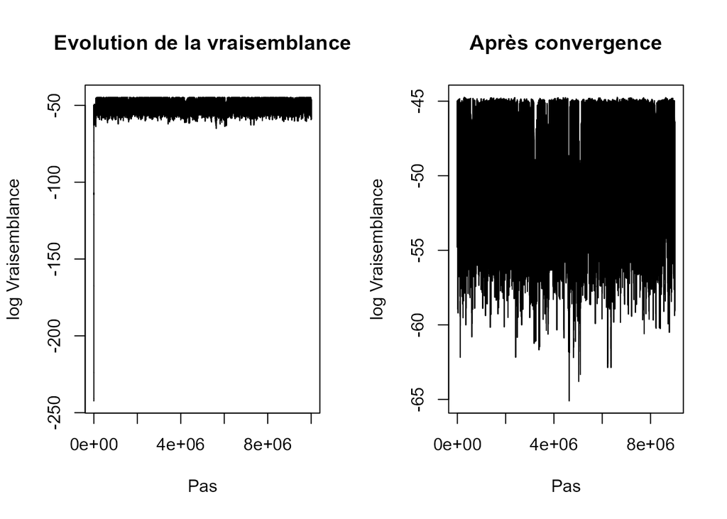

```r
# Evolution de la vraisemblance
par(mfrow = c(1, 2))
plot(chain[, length(theta_0) + 1], type = "l", main = "Evolution de la vraisemblance",
    xlab = "Pas", ylab = "log Vraisemblance")
burn_in <- iterations/10
plot(chain[-(1:burn_in), length(theta_0) + 1], type = "l", main = "Après convergence",
    xlab = "Pas", ylab = "log Vraisemblance")
```

Evolution des paramètres:

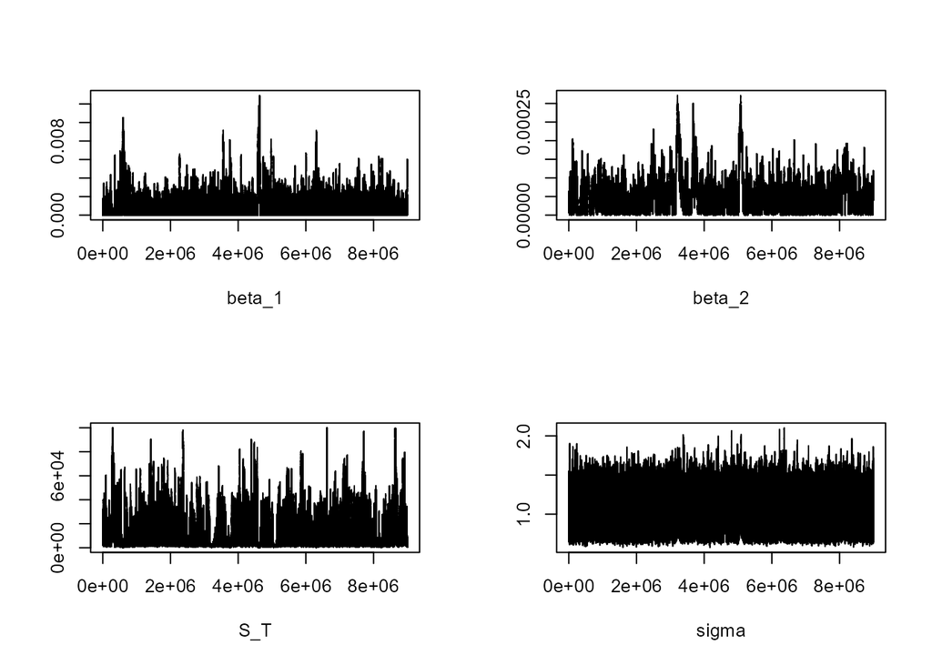

```r
par(mfrow = c(2, 2))
plot(chain[-(1:burn_in), 1], type = "l", main = "", xlab = "beta_1", ylab = "")
plot(chain[-(1:burn_in), 2], type = "l", main = "", xlab = "beta_2", ylab = "")
plot(chain[-(1:burn_in), 3], type = "l", main = "", xlab = "S_T", ylab = "")
plot(chain[-(1:burn_in), 4], type = "l", main = "", xlab = "sigma", ylab = "")
```

## Taux d’acceptation

```r
# Taux d'acceptation de la chaine de Markov
(acceptance <- 1 - mean(duplicated(chain[-(1:burn_in), ])))
```

```
## [1] 0.3499794
```

## Distribution des paramètres

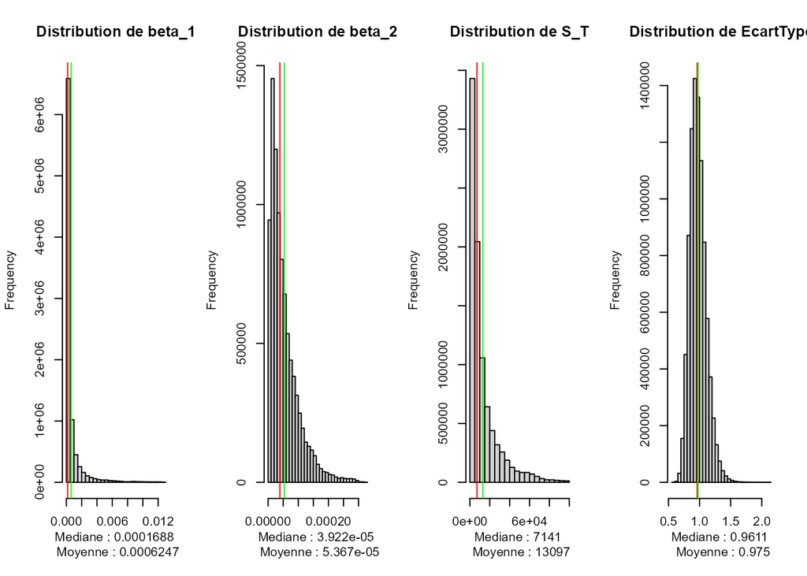

```r
par(mfrow = c(1, length(theta_0)))
for (i in 1:length(theta_0)) {
    Titre <- paste("Distribution de", names(theta_0)[i])
    Mediane <- format(median(chain[-(1:burn_in), i]), digits = 4)
    Moyenne <- format(mean(chain[-(1:burn_in), i]), digits = 4)
    hist(chain[-(1:burn_in), i], xlab = paste("Mediane :", Mediane, "\n", "Moyenne :",
        Moyenne), main = Titre)
    abline(v = Mediane, col = "red")
    abline(v = Moyenne, col = "green")
}
```

## Autocorrélation

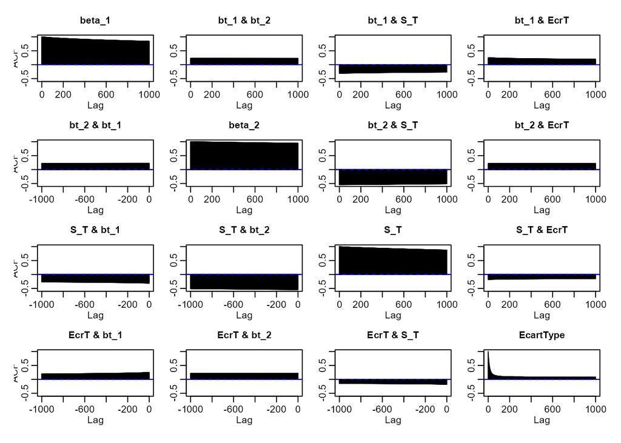

```r
acf(chain[-(1:burn_in), 1:(ncol(chain) - 2)], lag.max = 1000)
```

Éclaircie:

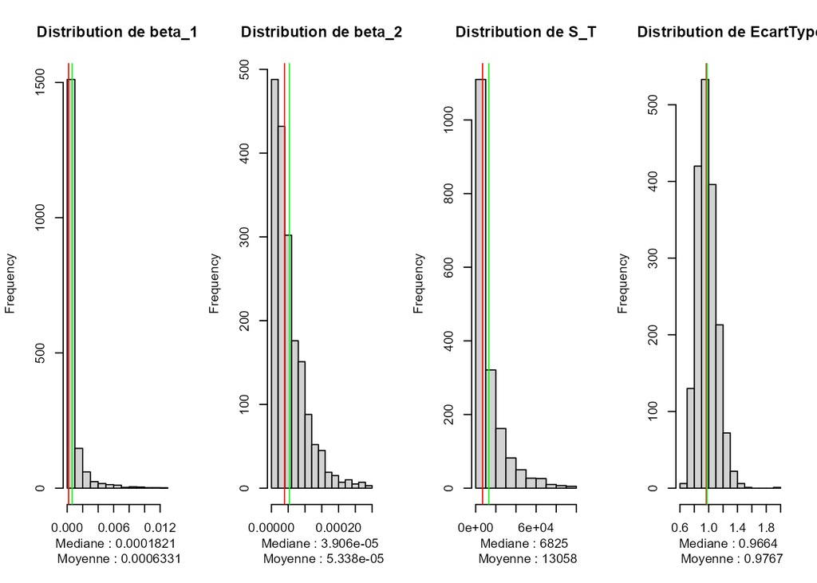

```r
# Distribution a posteriori. Elimination du prechauffage et de la
# vraisemblance, éclaircie.
posterior <- chain[-(1:burn_in), 1:(ncol(chain) - 2)][seq(1, iterations - burn_in,
    by = 5000), ]
# Nouvelle distribution des paramètres
par(mfrow = c(1, length(theta_0)))
for (i in 1:length(theta_0)) {
    Titre <- paste("Distribution de", names(theta_0)[i])
    Mediane <- format(median(posterior[, i]), digits = 4)
    Moyenne <- format(mean(posterior[, i]), digits = 4)
    hist(posterior[, i], xlab = paste("Mediane :", Mediane, "\n", "Moyenne :", Moyenne),
        main = Titre)
    abline(v = Mediane, col = "red")
    abline(v = Moyenne, col = "green")
}
```

Nouvelle autocorrélation:

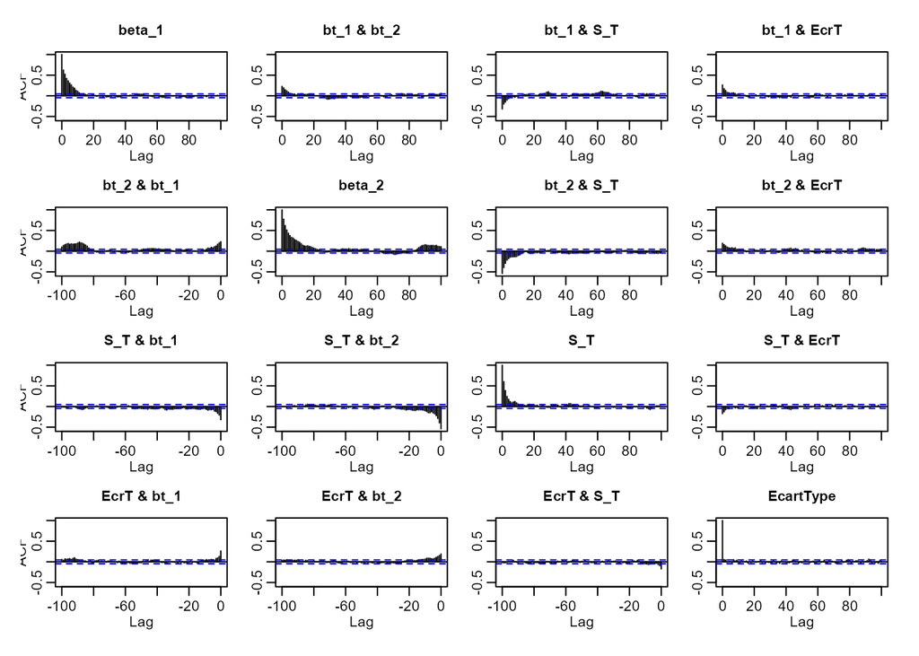

```r
acf(posterior, lag.max = 100)
```

# Nombre d’espèces estimé

```r
library("tidyverse")
library("entropart")
(S_est <- median(posterior[, 3]))
```

```
## [1] 6825.399
```

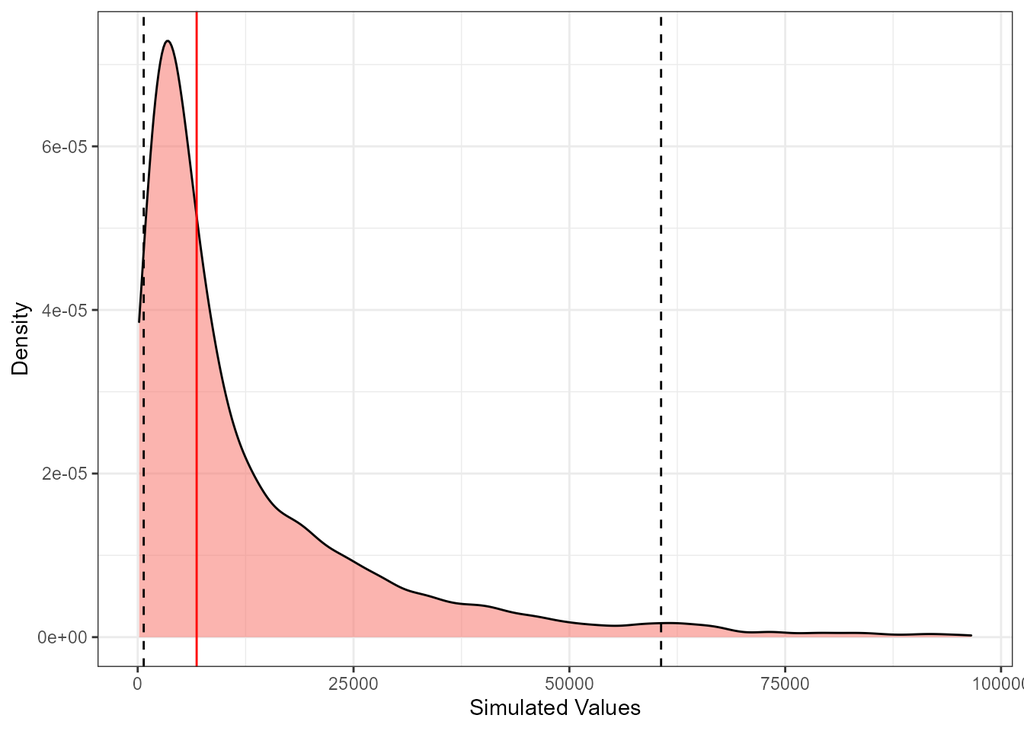

```r
as.SimTest(S_est, posterior[, 3]) %>%
    autoplot
```

# Prédictions

```r
# Graphique du nombre cumulé d'espèces observé (data) et prédit (paramètres du
# modèle)
Ajustement <- function(data, beta_1, beta_2, S_T, sigma) {
    # Stockage des S_i
    S <- numeric(length(data$Y))
    sum_S <- numeric(length(data$Y) + 1)
    sum_S[1] <- S_0
    # Calcul de S_i à chaque temps
    for (i in seq_along(data$Y)) {
        S[i] <- exp(log(S_T * beta_1 * T[i] + beta_2 * S_T * T[i] * Y[i] + beta_1 *
            T[i] * sum_S[i] + beta_2 * T[i] * Y[i] * sum_S[i]) + rnorm(1, sd = sigma))
        # Cumul des espèces découvertes
        sum_S[i + 1] <- sum_S[i] + S[i]
    }
    # Figure
    tibble(Année = c(1817, 1817 + 5 * data$Y), Estimé = sum_S, Observé = c(S_0, cumsum(data$S) +
        S_0)) %>%
        pivot_longer(cols = c("Estimé", "Observé")) %>%
        rename(`Nb espèces` = name, Nombre = value) %>%
        ggplot() + geom_line(aes(x = Année, y = Nombre, color = `Nb espèces`)) +
        scale_y_log10() %>%
            return
}
```

Qualité de prédiction du modèle estimé: les paramètres sont les médianes des distributions.

```r
# Médiane
beta_1 <- median(posterior[, 1])
beta_2 <- median(posterior[, 2])
(S_T <- median(posterior[, 3]))
```

```
## [1] 6825.399
```

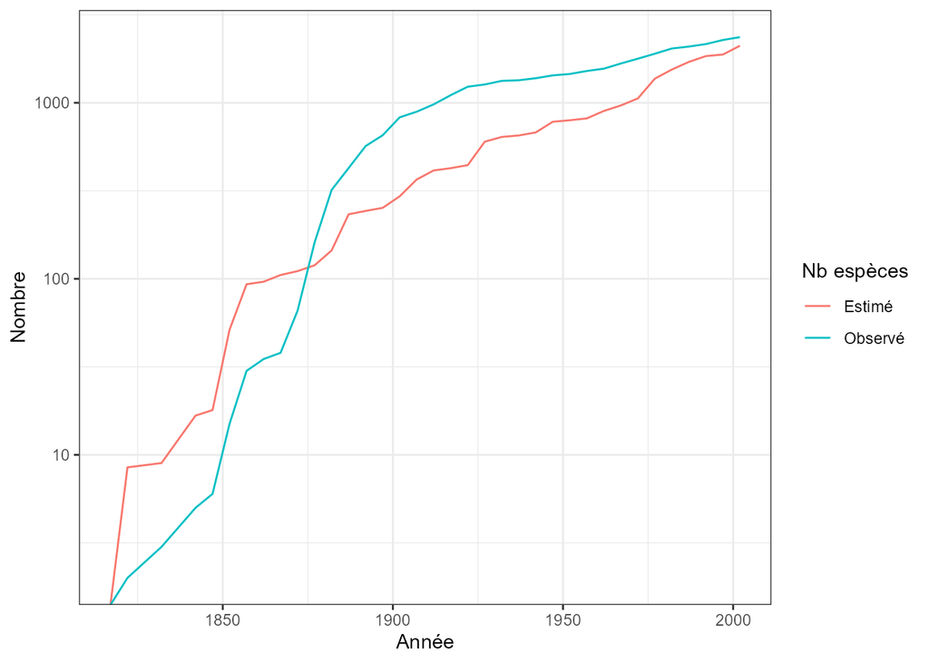

```r
sigma <- median(posterior[, 4])
Ajustement(data, beta_1, beta_2, S_T, sigma)
```

Les moyennes surestiment le nombre d’espèces.

```r
# Moyenne
beta_1 <- mean(posterior[, 1])
beta_2 <- mean(posterior[, 2])
(S_T <- mean(posterior[, 3]))
```

```
## [1] 13058.26
```

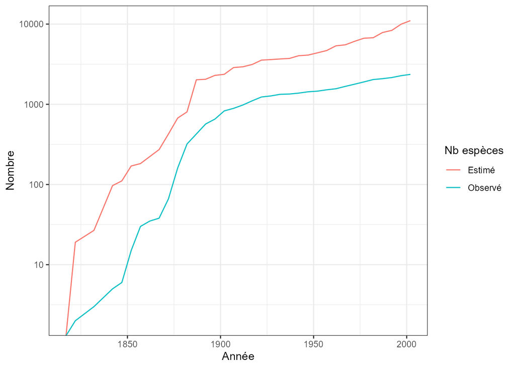

```r
sigma <- mean(posterior[, 4])
Ajustement(data, beta_1, beta_2, S_T, sigma)
```

La robustesse de l’estimation est évaluée en prenant les valeurs extrêmes du nombre d’espèces estimées.

```r
# Nombre d'espèces maximal
iteration <- which.max(posterior[, 3])
beta_1 <- posterior[iteration, 1]
beta_2 <- posterior[iteration, 2]
(S_T <- posterior[iteration, 3])
```

```
##      S_T
## 96549.53
```

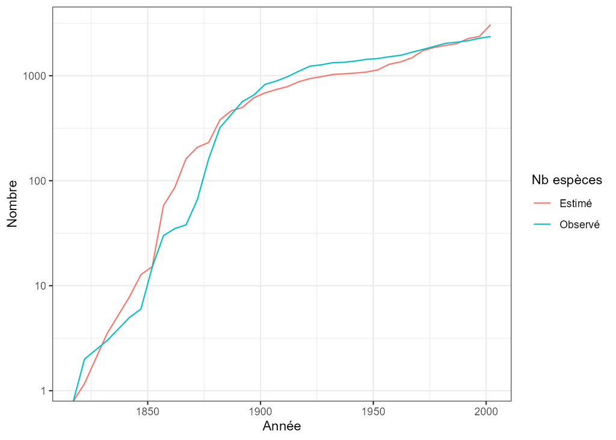

```r
sigma <- posterior[iteration, 4]
Ajustement(data, beta_1, beta_2, S_T, sigma)
```

```r
# Nombre d'espèces minimal
iteration <- which.min(posterior[, 3])
beta_1 <- posterior[iteration, 1]
beta_2 <- posterior[iteration, 2]
(S_T <- posterior[iteration, 3])
```

```
##      S_T
## 160.3766
```

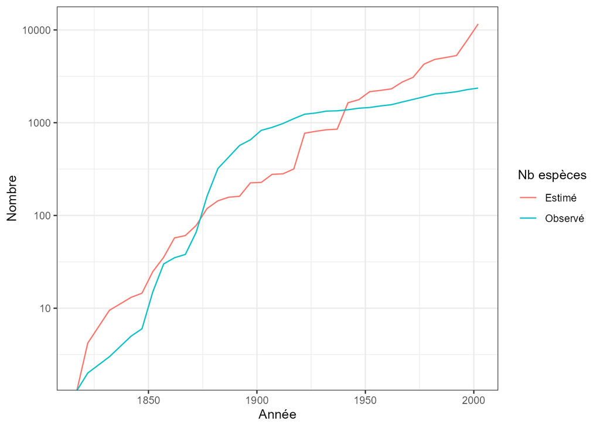

```r
sigma <- posterior[iteration, 4]
Ajustement(data, beta_1, beta_2, S_T, sigma)
```

L’estimation du nombre total d’espèces est corrélée négativement aux paramètres d’efficacité des taxonomistes: le modèle est donc peu discriminant.

```r
cor(posterior)
```

```
##               beta_1     beta_2        S_T  EcartType
## beta_1     1.0000000  0.2286864 -0.3193382  0.2631432
## beta_2     0.2286864  1.0000000 -0.5405572  0.1914022
## S_T       -0.3193382 -0.5405572  1.0000000 -0.1716990
## EcartType  0.2631432  0.1914022 -0.1716990  1.0000000
```